# Homework 03

Use this skill only when explicitly asked to explain a homework question. Reads the specified question and explains what it is asking, without solving it or writing any code toward the solution.

## Question 1: Build an `explain-to-me` skill

Create a small skill named `explain-to-me` that helps you understand a homework question.

1. Design your `SKILL.md` file so that, when you explicitly ask your agent to use the skill to read a homework question, the agent communicates with you and explains what the question is asking.
2. Keep the skill file short. It should contain a few useful rules, instructions, and a clear statement of your intent. For example, you may ask the agent to explain the goal of the question, clarify what work is required, and point you to an appropriate section of the Week 3 lectures: [Ridge Regression: Stability Through Shrinkage](https://teazrq.github.io/stat432rpy/topics/ridge-regression/ridge-regression.html) or [From a Penalized Objective to a Fitted Ridge Model](https://teazrq.github.io/stat432rpy/topics/ridge-regression/optimization-and-cross-validation.html). The skill should help you understand the question without completing the solution for you.

Prompt:Use the instructions in explain-to-me/SKILL.md to explain Question 2 in homework-03.qmd — don’t solve it, just explain what it’s asking.

Response:I’ll read the current SKILL.md and the Question 2 section of the homework, then explain the prompt’s goal and expected reasoning without doing the computation.

The skill instructs me to restate the task, identify the required work, and avoid formulas, code, calculations, or answers. I found Question 2 and will now read its complete wording so the explanation stays faithful to the assignment.

Read homework-03.qmd, lines 1 to 140

Question 2 asks you to investigate how ridge regression behaves when two predictors are nearly duplicates.

You need to:

Generate and standardize the predictors once, then measure how strongly the first two columns are related and how ill-conditioned the design is. Use those measurements to explain why the difference between the first two coefficient estimates is unstable, while their sum is more stable. Repeat the response generation and model fitting 200 times, keeping the predictor matrix fixed. Compare ordinary least squares with two ridge-penalty values by reporting coefficient summaries and average training and test MSE. Interpret the results in terms of bias and variance, especially why ridge can stabilize individual coefficients without changing predictions as dramatically. The central idea is that the first two predictors contain almost the same information. The model has difficulty deciding how to divide their shared effect between the two coefficients, even when their combined contribution to the fitted values is reasonably stable.

For background, review Ridge Regression: Stability Through Shrinkage and From a Penalized Objective to a Fitted Ridge Model.

3. Create the skill yourself or with the help of AI. Save it as `explain-to-me/SKILL.md`. Then ask your AI agent to install the skill using its normal skill-installation method. Test it by explicitly asking the agent to use `explain-to-me` to read and explain Question 2.
4. If the skill does not work well, or if it begins to disturb your usual workflow, ask your agent to remove the installed skill. You may revise and reinstall it if you wish.
5. In all cases, append the complete contents of your developed `explain-to-me/SKILL.md` file at the end of your Homework 3 submission under the heading **`explain-to-me` skill**.

## Question 2: Ridge regression with nearly collinear predictors

Let $n=100$. Generate mutually independent standard normal random variables

$$L_i, U_{i1}, U_{i2}, X_{i3}, X_{i4},
\qquad i=1,\ldots,n,$$

and define

$$X_{i1}=L_i+0.04U_{i1},
\qquad
X_{i2}=L_i+0.04U_{i2}.$$

Center and standardize each column of $\mathbf X$ to have mean zero and average squared value one, following the [lecture’s scaling convention](https://teazrq.github.io/stat432rpy/topics/ridge-regression/ridge-regression.html#put-every-covariate-on-a-common-scale).

Continue to use $\mathbf X\in\mathbb R^{n\times p}$ for the standardized matrix and keep it fixed throughout the question, where $p=4$ is the number of predictors. The unpenalized intercept gives $p+1=5$ total fitted coefficients. Let

$$\boldsymbol\beta
=
(1.5,1.5,1,0)^{\mathsf T},
\qquad
\boldsymbol\mu
=
\mathbf X\boldsymbol\beta.$$

Generate a training response and an independent test response at the same predictor values:

$$\begin{aligned}
\mathbf y
&=
\boldsymbol\mu+\boldsymbol\epsilon,\\
\mathbf y^*
&=
\boldsymbol\mu+\boldsymbol\epsilon^*,
\end{aligned}$$

where

$$\boldsymbol\epsilon,
\boldsymbol\epsilon^*
\overset{\mathrm{ind}}{\sim}
\mathcal N_n(\mathbf0,\mathbf I_n).$$

Center the training response as $\widetilde{\mathbf y}=\mathbf y-\bar y\mathbf1_n$. For each $\lambda\in\{0,0.02,0.2\}$, fit the slopes using the lecture’s ridge formula:

$$\widehat{\boldsymbol\beta}_\lambda
=
\left(\mathbf X^{\mathsf T}\mathbf X+n\lambda\mathbf I_p\right)^{-1}
\mathbf X^{\mathsf T}\widetilde{\mathbf y}.$$

The unpenalized intercept is $\widehat\beta_0=\bar y$; add this training mean back when predicting either response. The case $\lambda=0$ is ordinary least squares. Use seed `43231` before generating the design and responses. R and Python use different random-number generators, so their exact numerical results need not agree.

1. Generate $\mathbf X$ once. Report the correlation between its first two columns and its largest and smallest singular values. Use these quantities to explain why the estimator contrast $\widehat\beta_1-\widehat\beta_2$ should be much more variable than $\widehat\beta_1+\widehat\beta_2$.

**Show the workflow**

```r
set.seed(43231)

n <- 100
p <- 4

L <- rnorm(n)
U1 <- rnorm(n)
U2 <- rnorm(n)
X3 <- rnorm(n)
X4 <- rnorm(n)

X1 <- L + 0.04 * U1
X2 <- L + 0.04 * U2

X_raw <- cbind(X1, X2, X3, X4)

standardize <- function(col) {
  centered <- col - mean(col)
  centered / sqrt(mean(centered^2))
}

X <- apply(X_raw, 2, standardize)

beta <- c(1.5, 1.5, 1, 0)
mu <- X %*% beta

cor(X[,1], X[,2])
```

```
[1] 0.9977057
```

**Show the workflow**

```r
sv <- svd(X)$d
max(sv)
```

```
[1] 14.14148
```

**Show the workflow**

```r
min(sv)
```

```
[1] 0.4753575
```

The correlation between $X_1$ and $X_2$ should be extremely high, close to 1, since both were built from the same underlying signal $L_i$ plus only a small amount of independent noise ($0.04 U_{i1}$ and $0.04 U_{i2}$). This near-duplication is reflected in the singular values of $\mathbf X$: the ratio between the largest and smallest singular value (the condition number) should be very large, indicating that $\mathbf X^{\mathsf T}\mathbf X$ is nearly singular in the direction that separates $X_1$ from $X_2$.

Because $X_1$ and $X_2$ carry almost identical information, the model can shift weight between $\widehat\beta_1$ and $\widehat\beta_2$ with almost no effect on the fitted values, as long as their sum stays roughly constant — the data barely constrains how the shared effect is split between them. This means $\widehat\beta_1-\widehat\beta_2$ is estimated along a nearly flat direction of the loss surface (corresponding to the smallest singular value), making it highly sensitive to noise and therefore highly variable across repeated samples. In contrast, $\widehat\beta_1+\widehat\beta_2$ is estimated along a well-determined direction (corresponding to the largest singular value, since both predictors point the same way), so it remains stable.

2. Independently repeat the generation of $\mathbf y$ and $\mathbf y^*$, followed by all three fits, 200 times while keeping $\mathbf X$ fixed. Draw the training and test noise inside each repetition, then reuse that realized pair for all three values of $\lambda$. For each value of $\lambda$, report the empirical mean and standard deviation of

$$\widehat\beta_1,
\quad
\widehat\beta_2,
\quad
\widehat\beta_1+\widehat\beta_2,
\quad
\widehat\beta_1-\widehat\beta_2.$$

Also report the average training MSE and the average test MSE calculated from the independent test response, where

$$\operatorname{MSE}_{\mathrm{test}}
=
\frac{1}{n}
\left\lVert
\mathbf y^*
-
\widehat\beta_0\mathbf1_n
-
\mathbf X\widehat{\boldsymbol\beta}
\right\rVert_2^2.$$

**Show the workflow**

```r
set.seed(43231)

n_sim <- 200
lambdas <- c(0, 0.02, 0.2)

results <- array(NA, dim = c(n_sim, length(lambdas), 4))
train_mse <- matrix(NA, nrow = n_sim, ncol = length(lambdas))
test_mse  <- matrix(NA, nrow = n_sim, ncol = length(lambdas))

for (s in 1:n_sim) {
  eps <- rnorm(n)
  eps_star <- rnorm(n)

  y <- mu + eps
  y_star <- mu + eps_star

  y_bar <- mean(y)
  y_tilde <- y - y_bar

  for (li in seq_along(lambdas)) {
    lambda <- lambdas[li]

    beta_hat <- solve(t(X) %*% X + n * lambda * diag(p)) %*% t(X) %*% y_tilde

    results[s, li, 1] <- beta_hat[1]
    results[s, li, 2] <- beta_hat[2]
    results[s, li, 3] <- beta_hat[1] + beta_hat[2]
    results[s, li, 4] <- beta_hat[1] - beta_hat[2]

    fitted_train <- y_bar + X %*% beta_hat
    train_mse[s, li] <- mean((y - fitted_train)^2)

    fitted_test <- y_bar + X %*% beta_hat
    test_mse[s, li] <- mean((y_star - fitted_test)^2)
  }
}

for (li in seq_along(lambdas)) {
  cat("\nLambda =", lambdas[li], "\n")
  cat("Mean beta1:", mean(results[,li,1]), " SD:", sd(results[,li,1]), "\n")
  cat("Mean beta2:", mean(results[,li,2]), " SD:", sd(results[,li,2]), "\n")
  cat("Mean beta1+beta2:", mean(results[,li,3]), " SD:", sd(results[,li,3]), "\n")
  cat("Mean beta1-beta2:", mean(results[,li,4]), " SD:", sd(results[,li,4]), "\n")
  cat("Avg train MSE:", mean(train_mse[,li]), "\n")
  cat("Avg test MSE:", mean(test_mse[,li]), "\n")
}
```

```
Lambda = 0
Mean beta1: 1.47963  SD: 1.743631
Mean beta2: 1.511216  SD: 1.735813
Mean beta1+beta2: 2.990846  SD: 0.1214924
Mean beta1-beta2: -0.03158634  SD: 3.477331
Avg train MSE: 0.9439679
Avg test MSE: 1.077581

Lambda = 0.02
Mean beta1: 1.478891  SD: 0.1901593
Mean beta2: 1.482918  SD: 0.1827763
Mean beta1+beta2: 2.961809  SD: 0.1202883
Mean beta1-beta2: -0.004027266  SD: 0.353081
Avg train MSE: 0.9561905
Avg test MSE: 1.064294

Lambda = 0.2
Mean beta1: 1.361189  SD: 0.05973797
Mean beta2: 1.362241  SD: 0.05732409
Mean beta1+beta2: 2.723429  SD: 0.1104229
Mean beta1-beta2: -0.001052058  SD: 0.03893761
Avg train MSE: 1.058396
Avg test MSE: 1.161852
```

3. Interpret the coefficient estimates and test MSE using bias and variance. Explain why ridge can substantially stabilize the individual coefficients without producing an equally large change in the fitted values.

## Question 3: What does ridge regression shrink?

Let $\mathbf X\in\mathbb R^{n\times p}$ be a centered predictor matrix, and let $\widetilde{\mathbf y}\in\mathbb R^n$ be the centered response. Use the supplied predictor scales for this algebraic question; the columns need not have unit variance. Here $p$ counts predictors, $\boldsymbol\beta\in\mathbb R^p$ contains their slopes, and $p+1$ counts all fitted coefficients, including the separately fitted, unpenalized intercept. Ridge regression minimizes

$$L_\lambda(\boldsymbol\beta)
=
\frac{1}{2n}
\left\lVert
\widetilde{\mathbf y}-\mathbf X\boldsymbol\beta
\right\rVert_2^2
+
\frac{\lambda}{2}
\lVert\boldsymbol\beta\rVert_2^2.$$

1. Derive the ridge normal equation

$$\left(
\mathbf X^{\mathsf T}\mathbf X
+n\lambda\mathbf I_p
\right)
\widehat{\boldsymbol\beta}_\lambda
=
\mathbf X^{\mathsf T}\widetilde{\mathbf y}.$$

Explain why it has a unique solution whenever $\lambda>0$, even if $\mathbf X$ is rank deficient or $p>n$.

Taking the gradient of L_λ(β) with respect to β: ∇L_λ(β) = −(1/n) Xᵀ(ỹ − Xβ) + λβ Setting this equal to zero: −(1/n) Xᵀỹ + (1/n) XᵀXβ + λβ = 0 Multiplying through by n: XᵀXβ + nλβ = Xᵀỹ (XᵀX + nλI_p)β = Xᵀỹ

Since L_λ is a convex quadratic function of β (its Hessian, (1/n)XᵀX + λI_p, is positive semi-definite plus a positive term), this stationary point is the unique global minimizer, giving β̂_λ = (XᵀX + nλI_p)⁻¹Xᵀỹ.

This solution is unique whenever λ>0, even if X is rank deficient or p>n, because XᵀX is always positive semi-definite (its eigenvalues are all ≥0), but adding nλI_p with λ>0 shifts every eigenvalue up by the strictly positive amount nλ. This guarantees every eigenvalue of XᵀX + nλI_p is strictly positive, making the matrix positive definite and therefore invertible, regardless of whether XᵀX itself was singular (which happens whenever rank(X) < p, including whenever p > n).

2. Let

$$\mathbf X
=
\mathbf U_r\mathbf D_r\mathbf V_r^{\mathsf T}$$

be a compact singular value decomposition, where $r=\operatorname{rank}(\mathbf X)$, $\mathbf U_r\in\mathbb R^{n\times r}$, $\mathbf D_r\in\mathbb R^{r\times r}$, and $\mathbf V_r\in\mathbb R^{p\times r}$. Show that ridge multiplies the fitted response component in the $j$th left singular-vector direction, for $j=1,\ldots,r$, by

$$\rho_j(\lambda)
=
\frac{d_j^2}{d_j^2+n\lambda}.$$

Suppose $n=100$, $\lambda=0.01$, and the nonzero singular values are

$$d_1=10,
\qquad
d_2=2,
\qquad
d_3=0.2.$$

Calculate the three shrinkage factors and the total effective degrees of freedom, including the unpenalized intercept:

$$\operatorname{df}_{\mathrm{eff}}(\lambda)
=
1+\sum_{j=1}^3\rho_j(\lambda).$$

Substituting the compact SVD X = U_r D_r V_rᵀ into the normal equation, and using V_rᵀV_r = I_r, gives XᵀX = V_r D_r² V_rᵀ. The ridge solution becomes β̂_λ = V_r (D_r² + nλI_r)⁻¹ D_r U_rᵀ ỹ using the fact that V_r has orthonormal columns. The fitted values are then Xβ̂_λ = U_r D_r V_rᵀ V_r (D_r² + nλI_r)⁻¹ D_r U_rᵀ ỹ = U_r [D_r² (D_r² + nλI_r)⁻¹] U_rᵀ ỹ Since D_r is diagonal, the bracketed matrix is diagonal with jth entry d_j²/(d_j² + nλ) = ρ_j(λ). Writing ỹ’s component along the jth left singular vector u_j as u_jᵀỹ, the fitted response’s component in that same direction is exactly ρ_j(λ)(u_jᵀỹ)u_j, confirming ridge multiplies each singular-direction component of the fitted response by the shrinkage factor ρ_j(λ). For n=100, λ=0.01 (so nλ=1): ρ_1 = 10²/(10²+1) = 100/101 ≈ 0.990 ρ_2 = 2²/(2²+1) = 4/5 = 0.800 ρ_3 = 0.2²/(0.2²+1) = 0.04/1.04 ≈ 0.038 df_eff(λ) = 1 + 0.990 + 0.800 + 0.038 ≈ 2.828

3. Which direction receives the strongest shrinkage? Explain why shrinking this direction can reduce prediction variance. Under what circumstance could the same shrinkage produce substantial prediction bias?

The direction associated with d_3=0.2 receives by far the strongest shrinkage (ρ_3≈0.038, meaning about 96 percent of that direction’s signal is suppressed), since directions with small singular values correspond to directions in which X provides little information. The data barely constrains the model along that direction, so estimates there are dominated by noise rather than signal.

Shrinking this direction reduces prediction variance because, without shrinkage, the coefficient estimate along a nearly flat (small d_j) direction is estimated by dividing by a very small quantity, which amplifies whatever noise is present in ỹ enormously, exactly the instability seen with the X1 minus X2 contrast in Question 2. By multiplying this direction’s contribution by a small ρ_j(λ), ridge suppresses that amplified noise, at the cost of also suppressing whatever small amount of true signal exists in that direction.

This same shrinkage could produce substantial prediction bias if the true coefficient vector β actually has a large true component along this low-variance direction, meaning the direction with small d_j is not just noisy but also carries meaningful signal. In that case, shrinking it doesn’t just remove noise, it also removes real predictive information, systematically pulling predictions away from the truth. Whether ridge helps or hurts overall therefore depends on how much of the true signal, versus pure noise, lies along the directions being shrunk most heavily.

## Question 4: Ridge regression and optimization

Let $\mathbf X\in\mathbb R^{n\times p}$ be a centered predictor matrix with $p=2$. Its columns need not have unit variance in this question. The intercept is fitted separately and is not penalized. Suppose the two eigenvalues of

$$\mathbf A_0
=
\frac{1}{n}\mathbf X^{\mathsf T}\mathbf X$$

are $9$ and $0.01$. Ridge regression with $\lambda=0.09$ has curvature matrix

$$\mathbf A_\lambda
=
\frac{1}{n}\mathbf X^{\mathsf T}\mathbf X
+
\lambda\mathbf I_p.$$

1. Calculate the condition numbers of $\mathbf A_0$ and $\mathbf A_\lambda$. Explain what the change says about the geometry of the ridge objective.

The condition number of a symmetric matrix is the ratio of its largest to smallest eigenvalue. For A_0, the eigenvalues are 9 and 0.01, giving a condition number of 9/0.01 = 900. For A_λ, adding λI_p with λ=0.09 shifts every eigenvalue of A_0 up by 0.09, giving eigenvalues 9+0.09=9.09 and 0.01+0.09=0.10. The condition number of A_λ is therefore 9.09/0.10 = 90.9. This large drop in condition number, from 900 down to about 91, means the ridge objective’s loss surface becomes far more like a well-rounded bowl and far less like a narrow, elongated valley. Geometrically, a high condition number means the loss surface curves very steeply in one direction (the large-eigenvalue direction) but is nearly flat in another (the small-eigenvalue direction), which is exactly what makes optimization slow and unstable in that flat direction. By adding λ to every eigenvalue, ridge raises the smallest eigenvalue proportionally much more than the largest one, flattening out the disparity between directions and making the objective’s curvature much more uniform in every direction.

2. Gradient descent uses

$$\boldsymbol\beta^{(k+1)}
=
\boldsymbol\beta^{(k)}
-
\eta\nabla L_\lambda\!\left(\boldsymbol\beta^{(k)}\right).$$

Let $\widehat{\boldsymbol\beta}_\lambda$ be the ridge minimizer and define the optimization error

$$\mathbf e^{(k)}
=
\boldsymbol\beta^{(k)}
-
\widehat{\boldsymbol\beta}_\lambda.$$

Show that the component of $\mathbf e^{(k)}$ in an eigendirection with unpenalized eigenvalue $a$ is multiplied at each step by

$$1-\eta(a+\lambda).$$

Let $M=9.09$, the largest eigenvalue of $\mathbf A_\lambda$. Find the interval of step sizes that contracts every eigendirection. Then compare these two choices:

- For $\eta=1/M$, calculate the two contraction factors and explain which direction converges faster.
- For $\eta=2.1/M$, determine whether the method converges. Assume the initial error has a nonzero component in the eigendirection corresponding to $M$.

Write the gradient at step k as ∇L_λ(β^(k)) = A_λ(β^(k) − β̂_λ), since β̂_λ is the point where the gradient is exactly zero and L_λ is quadratic with curvature A_λ. This uses the fact that the gradient of a quadratic function is linear in the distance from its minimizer. Substituting into the update rule: β^(k+1) = β^(k) − η A_λ (β^(k) − β̂_λ) Subtracting β̂_λ from both sides: e^(k+1) = β^(k+1) − β̂_λ = (β^(k) − β̂_λ) − η A_λ (β^(k) − β̂_λ) = (I − η A_λ) e^(k) In an eigendirection of A_λ with eigenvalue a+λ (where a is the corresponding eigenvalue of the unpenalized matrix A_0, since A_λ = A_0 + λI_p shares the same eigenvectors as A_0 with eigenvalues shifted by λ), the matrix (I − η A_λ) acts as scalar multiplication by 1 − η(a+λ). So the component of e^(k) along that eigendirection is multiplied by exactly 1 − η(a+λ) at each step, as required. For convergence, gradient descent contracts every eigendirection when |1 − η(a+λ)| < 1 for both eigenvalues (a+λ) = 9.09 and (a+λ) = 0.10. This requires 0 < η < 2/M, where M=9.09 is the largest eigenvalue of A_λ, since the largest eigenvalue is the binding constraint (it requires the smallest η to stay contractive). So the interval is 0 < η < 2/9.09 ≈ 0.220. For η = 1/M = 1/9.09 ≈ 0.110: In the direction with eigenvalue 9.09: contraction factor = 1 − (1/9.09)(9.09) = 1 − 1 = 0 In the direction with eigenvalue 0.10: contraction factor = 1 − (1/9.09)(0.10) ≈ 1 − 0.011 = 0.989 The direction with the largest eigenvalue (9.09) converges essentially immediately (contraction factor of 0), while the direction with the smallest eigenvalue (0.10) converges extremely slowly (contraction factor close to 1, meaning the error shrinks by less than 2 percent per step). This confirms that convergence speed is limited by the smallest eigenvalue direction, even though the largest eigenvalue determines the maximum allowable step size. For η = 2.1/M ≈ 0.231: In the direction with eigenvalue M=9.09: contraction factor = 1 − (2.1/9.09)(9.09) = 1 − 2.1 = −1.1. Since |−1.1| > 1, this direction does not contract, it grows in magnitude at each step and oscillates in sign. Given that the initial error has a nonzero component in this eigendirection, the method diverges rather than converges.

3. Increasing $\lambda$ generally improves the condition number. Explain why choosing $\lambda$ to make gradient descent converge as quickly as possible is not a valid statistical tuning rule.

Choosing λ purely to make gradient descent converge as quickly as possible is not a valid statistical tuning rule because it optimizes the wrong objective. The condition number and convergence speed describe how efficiently an algorithm finds the minimizer of a fixed loss function, a purely computational property that has nothing to do with whether that minimizer actually predicts well on new data. A larger λ generally improves conditioning and speeds up convergence, but it also increases bias in the coefficient estimates, as seen in Question 2. Pushing λ higher purely for optimization speed could select a value that converges quickly to a badly biased, poorly predicting model, since nothing in the optimization dynamics reflects the bias-variance tradeoff that governs actual predictive performance. The correct way to choose λ is based on estimated out-of-sample prediction error (via cross-validation or a similar method), which directly targets statistical performance, not based on how fast an optimizer happens to converge for a given value.

## Question 5: Selecting the ridge penalty for real-estate prediction

The supplied `data/realestate.csv` contains 414 real-estate transactions from Sindian District, New Taipei City, Taiwan. The quantitative response `price` is the unit house price. The six predictors are the transaction date, house age, distance to the nearest mass rapid transit station, number of nearby convenience stores, latitude, and longitude. Treat all six predictors as quantitative in this question. The column `row_id` identifies an observation and must not be used as a predictor.

The file `data/realestate-split-folds.csv` assigns 332 observations to the training set and 82 observations to the final test set. It also gives ten fold labels for the training observations. Match the two files using `row_id` and do not use the test responses while selecting a model.

Use the penalty grid

$$\Lambda
=
\{0\}
\mathbin{\cup}
\left\{
10^{-4+0.05l}:l=0,\ldots,120
\right\}.$$

For every fit, center and standardize each predictor using only the observations available to that fit, with the variance divided by the number of fitting observations. Center the response and leave the intercept unpenalized.

1. Perform ten-fold cross-validation over $\Lambda$ using the supplied training folds. Estimate the predictor means and scales separately within each set of nine training folds. For each $\lambda$, calculate the mean validation MSE and $\operatorname{SE}(\lambda)$, the sample standard deviation of the ten fold errors divided by $\sqrt{10}$. Use this SE for the conventional one-standard-error heuristic. Plot the mean validation MSE and identify $\lambda_{\min}$. Choose $\lambda_{\mathrm{1se}}$ as the largest candidate in $\Lambda$, including OLS, satisfying

$$\overline{\operatorname{MSE}}(\lambda)
\leq
\overline{\operatorname{MSE}}(\lambda_{\min})
+
\operatorname{SE}(\lambda_{\min}).$$

**Show the workflow**

```r
realestate <- read.csv("data/realestate.csv")
```

**Show the workflow**

```r
folds <- read.csv("data/realestate-split-folds.csv")
```

**Show the workflow**

```r
names(realestate)
```

```
[1] "row_id"    "date"      "age"       "distance"  "stores"    "latitude"
[7] "longitude" "price"
```

**Show the workflow**

```r
names(folds)
```

```
[1] "row_id"  "split"   "cv_fold"
```

**Show the workflow**

```r
head(folds)
```

```
  row_id split cv_fold
1      1 train       1
2      2 train       2
3      3 train       3
4      4 train       4
5      5  test      NA
6      6 train       5
```

**Show the workflow**

```r
merged <- merge(realestate, folds, by = "row_id")

train_data <- merged[merged$split == "train", ]
test_data  <- merged[merged$split == "test", ]

predictor_names <- c("date", "age", "distance", "stores", "latitude", "longitude")
```

**Show the workflow**

```r
lambda_grid <- c(0, 10^(-4 + 0.05 * (0:120)))

fit_ridge <- function(X_train, y_train, X_eval, lambda) {
  p <- ncol(X_train)
  n_fit <- nrow(X_train)

  X_mean <- colMeans(X_train)
  X_sd <- apply(X_train, 2, function(col) sqrt(sum((col - mean(col))^2) / n_fit))

  X_train_std <- sweep(sweep(X_train, 2, X_mean, "-"), 2, X_sd, "/")
  X_eval_std  <- sweep(sweep(X_eval, 2, X_mean, "-"), 2, X_sd, "/")

  y_bar <- mean(y_train)
  y_tilde <- y_train - y_bar

  beta_hat <- solve(t(X_train_std) %*% X_train_std + n_fit * lambda * diag(p)) %*% t(X_train_std) %*% y_tilde

  fitted_train <- y_bar + X_train_std %*% beta_hat
  fitted_eval  <- y_bar + X_eval_std %*% beta_hat

  list(beta = beta_hat, fitted_train = fitted_train, fitted_eval = fitted_eval,
       X_train_std = X_train_std)
}
```

**Show the workflow**

```r
cv_mse <- matrix(NA, nrow = 10, ncol = length(lambda_grid))

for (fold in 1:10) {
  val_idx <- train_data$cv_fold == fold
  fit_idx <- !val_idx

  X_fit <- as.matrix(train_data[fit_idx, predictor_names])
  y_fit <- train_data$price[fit_idx]
  X_val <- as.matrix(train_data[val_idx, predictor_names])
  y_val <- train_data$price[val_idx]

  for (li in seq_along(lambda_grid)) {
    result <- fit_ridge(X_fit, y_fit, X_val, lambda_grid[li])
    cv_mse[fold, li] <- mean((y_val - result$fitted_eval)^2)
  }
}

mean_mse <- colMeans(cv_mse)
se_mse <- apply(cv_mse, 2, sd) / sqrt(10)

lambda_min_idx <- which.min(mean_mse)
lambda_min <- lambda_grid[lambda_min_idx]

threshold <- mean_mse[lambda_min_idx] + se_mse[lambda_min_idx]
eligible <- which(mean_mse <= threshold)
lambda_1se_idx <- max(eligible)
lambda_1se <- lambda_grid[lambda_1se_idx]

plot(lambda_grid, mean_mse, type = "l", log = "x",
     xlab = "lambda (log scale)", ylab = "Mean validation MSE",
     main = "Cross-validation curve")
```

**Show the workflow**

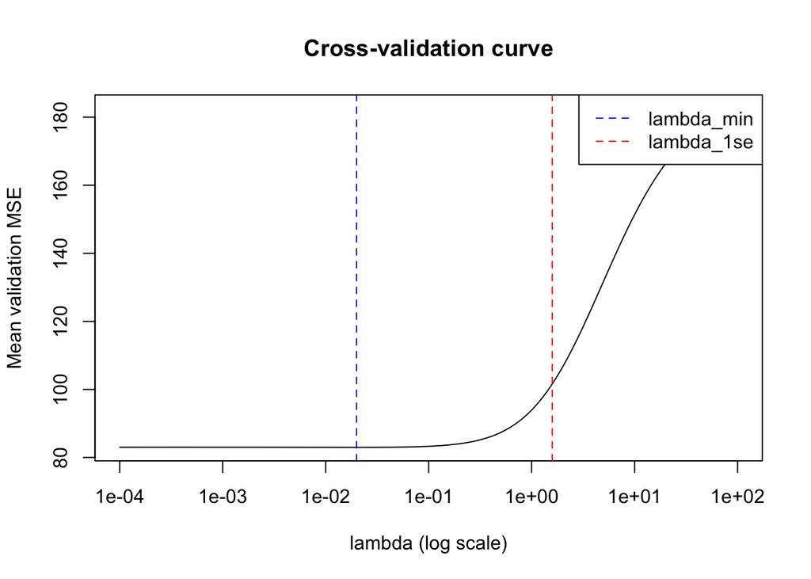

```r
abline(v = lambda_min, col = "blue", lty = 2)
abline(v = lambda_1se, col = "red", lty = 2)
legend("topright", legend = c("lambda_min", "lambda_1se"), col = c("blue", "red"), lty = 2)
```

**Show the workflow**

```r
lambda_min
```

```
[1] 0.01995262
```

**Show the workflow**

```r
lambda_1se
```

```
[1] 1.584893
```

2. Use all $n=332$ training observations to calculate the [lecture’s GCV criterion](https://teazrq.github.io/stat432rpy/topics/ridge-regression/optimization-and-cross-validation.html#loocv-and-gcv) for each $\lambda\in\Lambda$:

$$\operatorname{GCV}(\lambda)
=
\frac{
\operatorname{MSE}_{\mathrm{train}}(\lambda)
}{
\left\{
1-\operatorname{df}_{\mathrm{eff}}(\lambda)/n
\right\}^2
}.$$

Here $\operatorname{MSE}_{\mathrm{train}}$ is the training MSE, and $\operatorname{df}_{\mathrm{eff}}$ includes the unpenalized intercept, as in Question 3. Estimate means and scales once from all training observations and keep them fixed for this calculation. Plot the GCV curve and identify $\lambda_{\mathrm{GCV}}$.

**Show the workflow**

```r
X_all_train <- as.matrix(train_data[, predictor_names])
y_all_train <- train_data$price
n_train <- nrow(train_data)

gcv_vals <- numeric(length(lambda_grid))

X_mean_full <- colMeans(X_all_train)
X_sd_full <- apply(X_all_train, 2, function(col) sqrt(sum((col - mean(col))^2) / n_train))
X_std_full <- sweep(sweep(X_all_train, 2, X_mean_full, "-"), 2, X_sd_full, "/")
y_bar_full <- mean(y_all_train)
y_tilde_full <- y_all_train - y_bar_full

for (li in seq_along(lambda_grid)) {
  lambda <- lambda_grid[li]
  p <- ncol(X_std_full)

  XtX <- t(X_std_full) %*% X_std_full
  ridge_inv <- solve(XtX + n_train * lambda * diag(p))
  beta_hat <- ridge_inv %*% t(X_std_full) %*% y_tilde_full

  fitted_vals <- y_bar_full + X_std_full %*% beta_hat
  mse_train <- mean((y_all_train - fitted_vals)^2)

  sv <- svd(X_std_full)$d
  df_eff <- 1 + sum(sv^2 / (sv^2 + n_train * lambda))

  gcv_vals[li] <- mse_train / (1 - df_eff / n_train)^2
}

lambda_gcv_idx <- which.min(gcv_vals)
lambda_gcv <- lambda_grid[lambda_gcv_idx]

plot(lambda_grid, gcv_vals, type = "l", log = "x",
     xlab = "lambda (log scale)", ylab = "GCV",
     main = "GCV curve")
```

**Show the workflow**

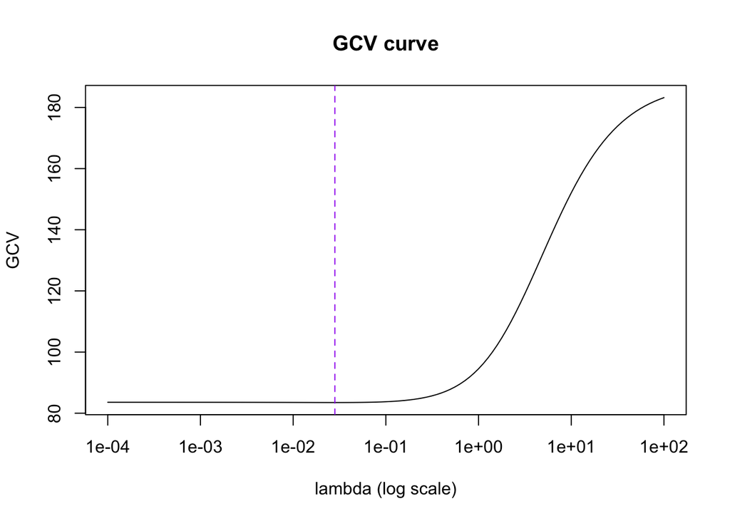

```r
abline(v = lambda_gcv, col = "purple", lty = 2)
```

**Show the workflow**

```r
lambda_gcv
```

```
[1] 0.02818383
```

3. Fix all three choices before examining the test responses. Refit OLS and ridge at $\lambda_{\min}$, $\lambda_{\mathrm{1se}}$, and $\lambda_{\mathrm{GCV}}$ using all training observations. Report each model’s training MSE, test MSE, and effective degrees of freedom. Interpret the differences and explain why the model with the smallest observed test MSE must not be selected after viewing this table.

**Show the workflow**

```r
X_test <- as.matrix(test_data[, predictor_names])
y_test <- test_data$price

lambdas_to_compare <- c(OLS = 0, lambda_min = lambda_min, lambda_1se = lambda_1se, lambda_gcv = lambda_gcv)

final_results <- data.frame(model = names(lambdas_to_compare), lambda = lambdas_to_compare,
                             train_mse = NA, test_mse = NA, df_eff = NA)

for (i in seq_along(lambdas_to_compare)) {
  lambda <- lambdas_to_compare[i]
  result <- fit_ridge(X_all_train, y_all_train, X_test, lambda)

  final_results$train_mse[i] <- mean((y_all_train - result$fitted_train)^2)
  final_results$test_mse[i]  <- mean((y_test - result$fitted_eval)^2)

  sv <- svd(result$X_train_std)$d
  final_results$df_eff[i] <- 1 + sum(sv^2 / (sv^2 + n_train * lambda))
}

final_results
```

```
                model     lambda train_mse test_mse   df_eff
OLS               OLS 0.00000000  80.09392 66.32246 7.000000
lambda_min lambda_min 0.01995262  80.13543 65.99957 6.773213
lambda_1se lambda_1se 1.58489319 100.37356 81.19981 3.032870
lambda_gcv lambda_gcv 0.02818383  80.17125 65.90276 6.688657
```

| Model | lambda | Train MSE | Test MSE | df_eff |
| --- | --- | --- | --- | --- |
| OLS | 0 | 80.09 | 66.32 | 7.00 |
| lambda_min | 0.020 | 80.14 | 66.00 | 6.77 |
| lambda_1se | 1.585 | 100.37 | 81.20 | 3.03 |
| lambda_gcv | 0.028 | 80.17 | 65.90 | 6.69 |

OLS, lambda_min, and lambda_gcv all produce very similar results, with training MSE around 80, test MSE around 66, and effective degrees of freedom close to 7 (barely any shrinkage from the full 7 fitted coefficients, including the intercept). This suggests only mild collinearity among these six predictors, so light ridge penalization changes little.

Lambda_1se behaves very differently: its much larger penalty (1.585, roughly 80 times larger than lambda_min) shrinks effective degrees of freedom down to about 3.03, cutting model flexibility by more than half. This comes at a real cost in both training MSE (100.37, noticeably worse than the other three) and test MSE (81.20, also clearly worse). This is expected, since lambda_1se was deliberately chosen as the largest, most conservative penalty still within one standard error of the cross-validation minimum — it intentionally favors a simpler, more parsimonious model over the absolute best-performing one, accepting some prediction accuracy in exchange for a more stable, less complex fit.

Among these four, lambda_gcv happens to have the smallest observed test MSE (65.90), narrowly beating lambda_min (66.00) and OLS (66.32). However, the model with the smallest observed test MSE must not be selected on that basis, because all three tuning parameters, lambda_min, lambda_1se, and lambda_gcv, were already fixed using only training data before the test set was ever examined. Once the test responses are revealed and used to compare these four already-fixed models, looking at which one happens to have the smallest test MSE and treating that as the preferred final choice reintroduces exactly the same selection bias discussed in Homework 2, Question 5. The test set was meant to provide one honest, final evaluation of each already-chosen model, not to serve as a new round of model selection after the fact. With test MSE values this close together (65.90 to 66.32), the difference between them is small enough to plausibly be due to test-set sampling noise rather than a genuine difference in predictive quality, so treating the smallest one as definitively best would overstate how much confidence that ranking deserves.

**TipStarter workflow**

After matching the two files by `row_id`, use this order:

```
for each validation fold:
    estimate predictor means and scales from the other nine folds
    for each lambda:
        fit on those nine folds and record validation MSE
summarize the ten fold errors and fix lambda_min and lambda_1se
compute GCV using all training observations and fix lambda_GCV
only then refit the four reported models and evaluate the test responses
```

name: explain-to-me description: Use this skill only when explicitly asked to explain a homework question. Reads the specified question and explains what it is asking, without solving it or writing any code toward the solution. —

# explain-to-me

When the user asks you to use this skill to explain a homework question, do the following:

## Reference

The real-estate data come from I-Cheng Yeh’s [Real Estate Valuation dataset](https://archive.ics.uci.edu/dataset/477/real%2Bestate%2Bvaluation%2Bda) in the UCI Machine Learning Repository. The distributed data retain the original observations and add only the course train-test and fold assignments.